# Canadian Air Pollutant Emmision Inventory by Jenny Lu

# Multivariate Analysis

### Talk about some of the relationships you observed in this part of the investigation. Were there features that strengthened each other in terms of looking at your feature(s) of interest?

Overall, dust from unpaved roads (emissions resulting from the re-suspension of particulate matter by vehicles travelling on unpaved roads) are by far the greatest contributor to TPM and the emissions have mostly increased steadily over the past 15 years.

Soil disturbance on construction sites is the second greatest contributor to PM emission in recent years. There is an interesting plummet from 1997-1998 and then a large increase from 2005-2006. I’m not sure what happened during these period in time because Canada’s GDP from construction increased continually throughout 1997-2014.

Dust from paved roads (emissions resulting from the re-suspension of particulate matter by vehicles travelling on unpaved roads) surpassed emissions from agriculture last year to be the third largest contributor to TPM and has also been steadily increasing over the past 15 years.

The increasing trend in NH3 emissions appears to be almost entirely driven by the agricultural sector. Primary sources of NH3 in agriculture are from animal production and fertilizer.

### Were there any interesting or surprising interactions between features?

Open source emissions of TPM from agriculture has strangely declined steadily. This is interesting because Canada’s GDP from agriculture has mostly increased during this time. The decline may be from better farming technology or maybe some sort of error in how the data is collected or reported.

Another interesting point of interest is how insignificant the contributions from mine tailings are, even with the recent increased development of resource extraction industries in Alberta. The true cost, from a pollution point of view, of the increased industrial activity in Alberta is probably captured in particulate matter pollution due to construction and dust from increased road usage (especially unpaved).

# Final Plots and Summary

All 14 pollutants that are reported in the APEI have decreased over time - save for particulate matter and ammonia. Of all particulate matter pollution, PM2.5 is especially hazardous to health due to its small size and potential to infiltrate the alveoli in the lungs. Ammonia is very harmful to the environment and can also be hazardous to health if particle size falls within PM2.5 category.

### Plot One

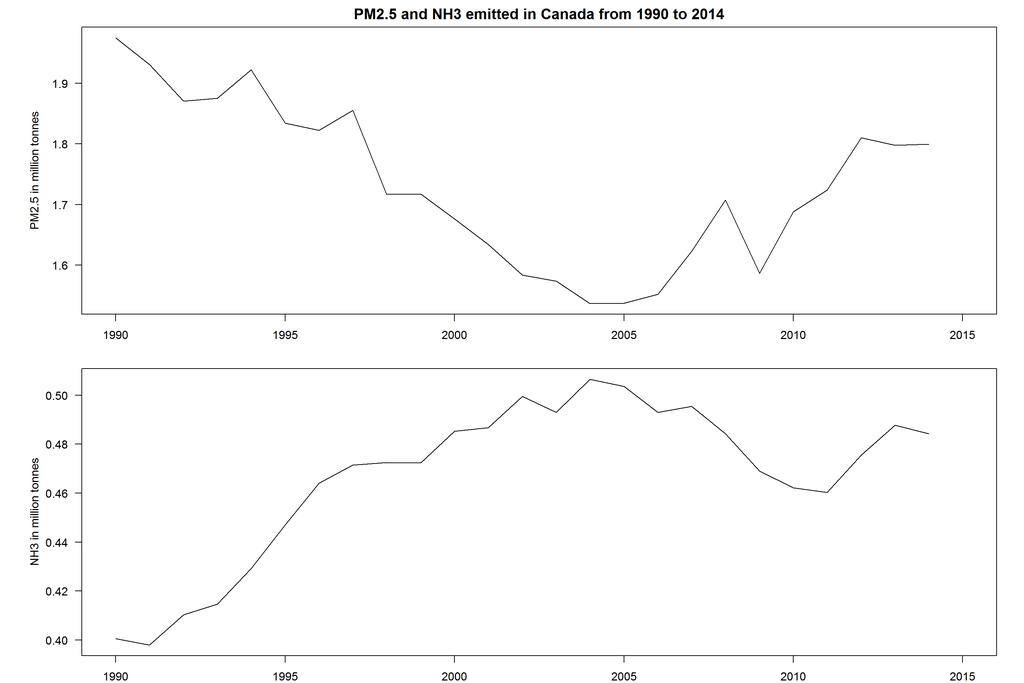

### Description One

From 1990 to 2014, Canada’s NH3 emissions increased by 21% (84 kt). Emissions of PM2.5 steadily decreased from 1990 to 2005 and then increased.

### Plot Two

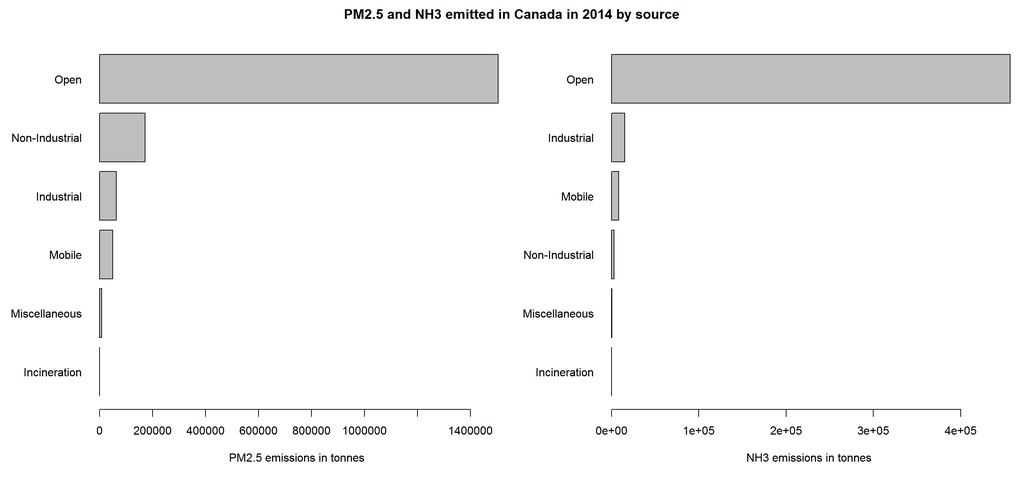

### Description Two

The main source of both PM2.5 and ammonia emissions is from open sources. Open sources accounted for 84% (1.5 Mt) of total PM2.5 emissions and 94% (460 kt) of total ammonia emissions.

### Plot Three

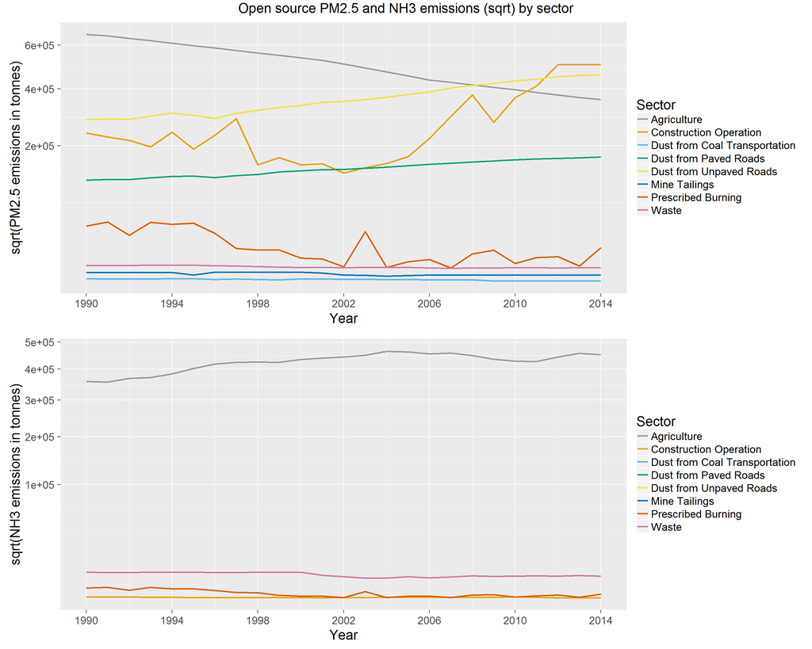

### Description Three

The increase in ammonia emissions is almost entirely driven by emissions from animal production and fertilizer application within the agriculture sector. Animal production, which dominates the emissions throughout the time series, experienced a steady increase in emissions from 1990 to 2005, followed by a decrease from 2006 to 2014. Emissions from fertilizer application, however, have been rapidly increasing since 2006, due to an increase in consumption of synthetic nitrogen fertilizers.

# Reflection

I did some data wrangling beforehand in Python. The data was only available for download as individual CSV files for each year and each geographical area (~330 files). I wrote a script (mush.py) to combine all regional CSVs, as well as remove unwanted French and unit columns. I then combined all the regional files using mastermush.py into one giant dataset.

Because I combined so many individual reports, there was a lot of data to examine in the overall dataset and I didn’t look at it from every angle. In retrospect, I probably didn’t need the regional data for now because I didn’t get around to looking at individual regions.

I first explored Canada-wide data because I wanted to begin with general scope and narrow it down later. I first looked at the trends of all pollutants over time and then focused on the ones which increased (i.e. PM and NH3). Then, I looked more closely at the sectors and sources which contributed to the increase of those pollutants.

In the future I would like to explore the data in different regions. I would also like to examine the pollutants that decreased over time in addition to the ones that increased. It would be interesting to try and match significant increases or decreases with any legislation that was introduced around the time.